# Starbucks Capstone Challenge

1. Introduction

2. Problem Statement

- A. Strategy
- B. Metrics
- C. Refinement

3. Data Sets

- A. Portfolio.json
- B. Profile.json
- C. Transcript.json

4. Data Analysis

- Data Exploration & Visualization
  - A. Portfolio.json
  - B. Profile.json
  - C. Transcript.json

5. Methodology

- A. Data Preprocessing
- B. Storing Data
- C. Implementation
  - 1- Correlation between income and purchase
  - 2- Purchases by demographic groups
- D. Refinement

6. Results

- A. Answering Questions
- B. Justification

7. Conclusion

- A. Reflection
- B. Improvement

## 1. Introduction

This data set contains simulated data that mimics customer behavior on the Starbucks rewards mobile app. Once every few days, Starbucks sends out an offer to users of the mobile app. An offer can be merely an advertisement for a drink or an actual offer such as a discount or BOGO (buy one get one free). Some users might not receive any offer during certain weeks.

A. In a *BOGO offer*, a user needs to spend a certain amount to get a reward equal to that threshold amount.

B. In a *discount*, a user gains a reward equal to a fraction of the amount spent.

C. In an *informational offer*, there is no reward, but **neither** is there a requisite amount that the user is expected to spend. Offers can be delivered via multiple channels.

Not all users receive the same offer, and that is the challenge to solve with this data set.

The program used to create the data simulates how people make purchasing decisions and how those decisions are influenced by promotional offers.

Each person in the simulation has some hidden traits that influence their purchasing patterns and are associated with their observable traits. People produce various events, including receiving offers, opening offers, and making purchases.

Your task is to combine transaction, demographic and offer data to determine which demographic groups respond best to which offer type. This data set is a simplified version of the real Starbucks app because the underlying simulator only has **one** product whereas Starbucks actually sells dozens of products.

Every offer has a validity period before the offer expires. As an example, a BOGO offer might be valid for only 5 days. *You'll see in the data set that informational offers have a validity period even though these ads are merely providing information about a product; for example, if an informational offer has 7 days of validity, you can assume the customer is feeling the influence of the offer for 7 days after receiving the advertisement.*

You'll be given transactional data showing user purchases made on the app including the timestamp of purchase and the amount of money spent on a purchase. This transactional data also has a record for each offer that a user receives as well as a record for when a user actually views the offer. There are also records for when a user completes an offer.

Keep in mind as well that someone using the app might make a purchase through the app without having received an offer or seen an offer.

### Example

To give an example, a user could receive a discount offer buy 10 dollars get 2 off on Monday. The offer is valid for 10 days from receipt. If the customer accumulates at least 10 dollars in purchases during the validity period, the customer completes the offer.

However, there are a few things to watch out for in this data set. Customers do not opt into the offers that they receive; in other words, a user can receive an offer, never actually view the offer, and still complete the offer. For example, a user might receive the "buy 10 dollars get 2 dollars off offer", but the user never opens the offer during the 10 day validity period. The customer spends 15 dollars during those ten days. There will be an offer completion record in the data set; however, the customer was not influenced by the offer because the customer never viewed the offer.

### Cleaning

This makes data cleaning especially important and tricky.

You'll also want to take into account that some demographic groups will make purchases even if they don't receive an offer. From a business perspective, if a customer is going to make a 10 dollar purchase without an offer anyway, you wouldn't want to send a buy 10 dollars get 2 dollars off offer. You'll want to try to assess what a certain demographic group will buy when not receiving any offers.

### Final Advice

Because this is a capstone project, you are free to analyze the data any way you see fit. For example, you could build a machine learning model that predicts how much someone will spend based on demographics and offer type. Or you could build a model that predicts whether or not someone will respond to an offer. Or, you don't need to build a machine learning model at all. You could develop a set of heuristics that determine what offer you should send to each customer (i.e., 75 percent of women customers who were 35 years old responded to offer A vs 40 percent from the same demographic to offer B, so send offer A).

## 2. Problem Statement

The basic task is to use the data to identify which groups of people are most responsive to each type of offer.

### A. Strategy

As mentioned above in the "Final Advice" section, I have decided to develop a set of heuristics to help determine what offer should be sent to each customer through the following steps:

1- Combine transaction, demographic and offer data after necessary cleaning.

2- Find correlation between income and purchase.

3- Determine which demographic group pays more in purchases.

### B. Metrics

- Purchases are measured by transaction amount.
- Response is measured by number of completed offers.

### C. Refinement

A combination of age and gender is used to classify customers into more specific groups so that their response to different offer types can be measured more accurately, not just the purchases they made.Thus, can determine which demographic groups respond best to which offer type.

## 3. Data Sets

The data is contained in three files:

- portfolio.json - containing offer ids and meta data about each offer (duration, type, etc.)
- profile.json - demographic data for each customer
- transcript.json - records for transactions, offers received, offers viewed, and offers completed

Here is the schema and explanation of each variable in the files:

### A. Portfolio.json

Offers sent during 30-day test period (10 offers x 6 fields)

- id (string) - offer id
- offer_type (string) - type of offer ie BOGO, discount, informational (an advertisement for a drink).
- difficulty (int) - minimum money required to be spent to complete an offer and receive reward.
- reward (int) - reward given for completing an offer (money awarded for the amount spent).
- duration (int) - time for offer to be open, in days.
- channels (list of strings) - web, email, mobile, social.

### B. Profile.json

Rewards program users (17000 users x 5 fields)

- age (int) - age of the customer. Missing value encoded as 118
- became_member_on (int) - date when customer created an app account (date format YYYYMMDD)
- gender (str) - gender of the customer (note some entries contain 'O' for other rather than M or F)
- id (str) - customer id
- income (float) - customer's income

### C. Transcript.json

- event (str) - record description (ie transaction, offer received, offer viewed, offer completed).
- person (str) - customer id
- time (int) - time in hours since start of test. The data begins at time t=0
- value - (dict of strings) - different values depending on event type:
  - offer id: (string/hash) not associated with any "transaction"
  - amount: (numeric) money spent in "transaction"
  - reward: (numeric) money gained from "offer completed"

**Note:** If you are using the workspace, you will need to go to the terminal and run the command `conda update pandas` before reading in the files. This is because the version of pandas in the workspace cannot read in the transcript.json file correctly, but the newest version of pandas can. You can access the termnal from the orange icon in the top left of this notebook.

You can see how to access the terminal and how the install works using the two images below. First you need to access the terminal:

[figure not shown]

Then you will want to run the above command:

[figure not shown]

Finally, when you enter back into the notebook (use the jupyter icon again), you should be able to run the below cell without any errors.

## 4. Data Analysis

### Data Exploration & Visualization

```python
# Import Libraries
import pandas as pd
import numpy as np
import math
import json
import matplotlib.pyplot as plt
import seaborn as sb
% matplotlib inline

# Read in the json files
portfolio = pd.read_json('data/portfolio.json', orient='records', lines=True)
profile = pd.read_json('data/profile.json', orient='records', lines=True)
transcript = pd.read_json('data/transcript.json', orient='records', lines=True)
```

#### A. Portfolio.json

```python
portfolio.shape
```

```
(10, 6)
```

```python
portfolio.head(10)
```

|  | channels | difficulty | duration | id | offer_type | reward |
| --- | --- | --- | --- | --- | --- | --- |
| 0 | [email, mobile, social] | 10 | 7 | ae264e3637204a6fb9bb56bc8210ddfd | bogo | 10 |
| 1 | [web, email, mobile, social] | 10 | 5 | 4d5c57ea9a6940dd891ad53e9dbe8da0 | bogo | 10 |
| 2 | [web, email, mobile] | 0 | 4 | 3f207df678b143eea3cee63160fa8bed | informational | 0 |
| 3 | [web, email, mobile] | 5 | 7 | 9b98b8c7a33c4b65b9aebfe6a799e6d9 | bogo | 5 |
| 4 | [web, email] | 20 | 10 | 0b1e1539f2cc45b7b9fa7c272da2e1d7 | discount | 5 |
| 5 | [web, email, mobile, social] | 7 | 7 | 2298d6c36e964ae4a3e7e9706d1fb8c2 | discount | 3 |
| 6 | [web, email, mobile, social] | 10 | 10 | fafdcd668e3743c1bb461111dcafc2a4 | discount | 2 |
| 7 | [email, mobile, social] | 0 | 3 | 5a8bc65990b245e5a138643cd4eb9837 | informational | 0 |
| 8 | [web, email, mobile, social] | 5 | 5 | f19421c1d4aa40978ebb69ca19b0e20d | bogo | 5 |
| 9 | [web, email, mobile] | 10 | 7 | 2906b810c7d4411798c6938adc9daaa5 | discount | 2 |

```python
portfolio.info()
```

```
<class 'pandas.core.frame.DataFrame'>
RangeIndex: 10 entries, 0 to 9
Data columns (total 6 columns):
channels      10 non-null object
difficulty    10 non-null int64
duration      10 non-null int64
id            10 non-null object
offer_type    10 non-null object
reward        10 non-null int64
dtypes: int64(3), object(3)
memory usage: 560.0+ bytes
```

```python
portfolio.describe()
```

|  | difficulty | duration | reward |
| --- | --- | --- | --- |
| count | 10.000000 | 10.000000 | 10.000000 |
| mean | 7.700000 | 6.500000 | 4.200000 |
| std | 5.831905 | 2.321398 | 3.583915 |
| min | 0.000000 | 3.000000 | 0.000000 |
| 25% | 5.000000 | 5.000000 | 2.000000 |
| 50% | 8.500000 | 7.000000 | 4.000000 |
| 75% | 10.000000 | 7.000000 | 5.000000 |
| max | 20.000000 | 10.000000 | 10.000000 |

```python
portfolio.offer_type.value_counts()
```

```
bogo             4
discount         4
informational    2
Name: offer_type, dtype: int64
```

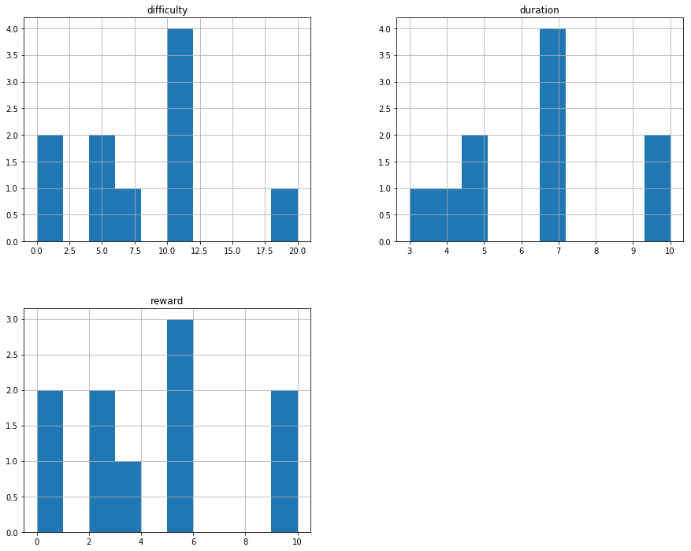

```python
portfolio.hist(figsize= (15,12));  #histogram of whole dataset
```

*Every thing looks good. No cleaning required.*

#### B. Profile.json

```python
profile.head()
```

|  | age | became_member_on | gender | id | income |
| --- | --- | --- | --- | --- | --- |
| 0 | 118 | 20170212 | None | 68be06ca386d4c31939f3a4f0e3dd783 | NaN |
| 1 | 55 | 20170715 | F | 0610b486422d4921ae7d2bf64640c50b | 112000.0 |
| 2 | 118 | 20180712 | None | 38fe809add3b4fcf9315a9694bb96ff5 | NaN |
| 3 | 75 | 20170509 | F | 78afa995795e4d85b5d9ceeca43f5fef | 100000.0 |
| 4 | 118 | 20170804 | None | a03223e636434f42ac4c3df47e8bac43 | NaN |

```python
profile.shape
```

```
(17000, 5)
```

```python
profile.info()
```

```
<class 'pandas.core.frame.DataFrame'>
RangeIndex: 17000 entries, 0 to 16999
Data columns (total 5 columns):
age                 17000 non-null int64
became_member_on    17000 non-null int64
gender              14825 non-null object
id                  17000 non-null object
income              14825 non-null float64
dtypes: float64(1), int64(2), object(2)
memory usage: 664.1+ KB
```

*Same number of missing gender & income values. Those probably belong to customers of unknown age (118)*

```python
profile.describe()
```

|  | age | became_member_on | income |
| --- | --- | --- | --- |
| count | 17000.000000 | 1.700000e+04 | 14825.000000 |
| mean | 62.531412 | 2.016703e+07 | 65404.991568 |
| std | 26.738580 | 1.167750e+04 | 21598.299410 |
| min | 18.000000 | 2.013073e+07 | 30000.000000 |
| 25% | 45.000000 | 2.016053e+07 | 49000.000000 |
| 50% | 58.000000 | 2.017080e+07 | 64000.000000 |
| 75% | 73.000000 | 2.017123e+07 | 80000.000000 |
| max | 118.000000 | 2.018073e+07 | 120000.000000 |

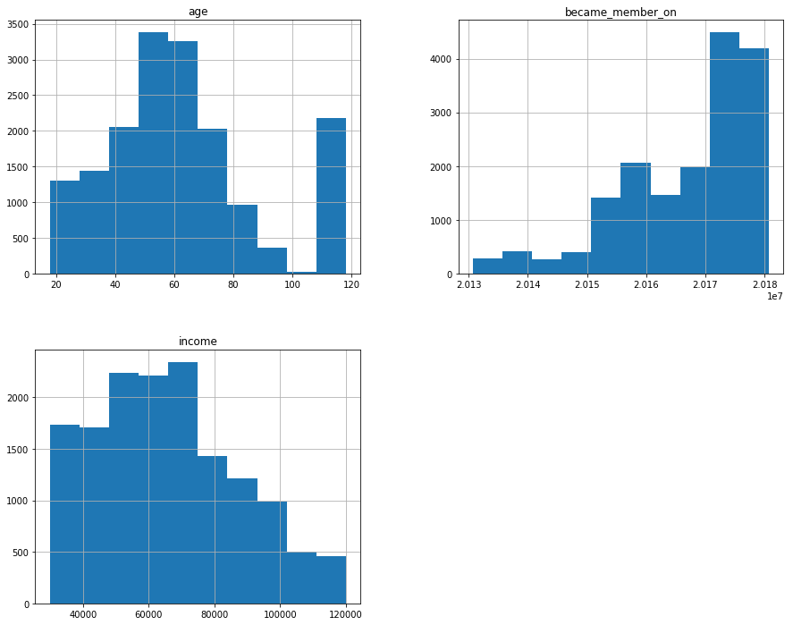

```python
profile.hist(figsize= (15,12));  #histogram of whole dataset
```

- Age of most customers falls between 50 and 70 years.
- Most customers beacme members between 2017 & 2018.
- Income of most customers falls between 50,000 and 75,000.

```python
profile[profile.isna().any(axis=1)]
```

|  | age | became_member_on | gender | id | income |
| --- | --- | --- | --- | --- | --- |
| 0 | 118 | 20170212 | None | 68be06ca386d4c31939f3a4f0e3dd783 | NaN |
| 2 | 118 | 20180712 | None | 38fe809add3b4fcf9315a9694bb96ff5 | NaN |
| 4 | 118 | 20170804 | None | a03223e636434f42ac4c3df47e8bac43 | NaN |
| 6 | 118 | 20170925 | None | 8ec6ce2a7e7949b1bf142def7d0e0586 | NaN |
| 7 | 118 | 20171002 | None | 68617ca6246f4fbc85e91a2a49552598 | NaN |
| 9 | 118 | 20161122 | None | 8974fc5686fe429db53ddde067b88302 | NaN |
| 10 | 118 | 20170824 | None | c4863c7985cf408faee930f111475da3 | NaN |
| 11 | 118 | 20150919 | None | 148adfcaa27d485b82f323aaaad036bd | NaN |
| 17 | 118 | 20170801 | None | 744d603ef08c4f33af5a61c8c7628d1c | NaN |
| 23 | 118 | 20170907 | None | 2b826eba31074a059d63b0ae8f50b7d5 | NaN |
| 26 | 118 | 20170330 | None | 65aba5c617294649aeb624da249e1ee5 | NaN |
| 36 | 118 | 20160707 | None | 4beeb3ed64dd4898b0edf2f6b67426d3 | NaN |
| 39 | 118 | 20180113 | None | 25c906289d154b66bf579693f89481c9 | NaN |
| 44 | 118 | 20141111 | None | 5b8f1f0e0930464f93bb55e59b5a04e0 | NaN |
| 45 | 118 | 20170511 | None | 8be4463721e14d7fa600686bf8c8b2ed | NaN |
| 54 | 118 | 20170528 | None | 81ac76e4f2fe4a6bb5ebdc0f19cecc56 | NaN |
| 56 | 118 | 20171013 | None | 020d3a52b9ce432ea5f98fc58e9bfcc4 | NaN |
| 57 | 118 | 20151220 | None | 4be1127413db496d8103c783ae72058b | NaN |
| 80 | 118 | 20170918 | None | 9d8d6bb2fc544a9c802888971ee3e8b1 | NaN |
| 84 | 118 | 20150920 | None | a89752cdfdf24779aa22faa2bc24e7c2 | NaN |
| 96 | 118 | 20160806 | None | 53bac762af27471eb294ff89ca1bae2c | NaN |
| 103 | 118 | 20170223 | None | 488773cae11f4b71875bfccd4e3e99f2 | NaN |
| 104 | 118 | 20170823 | None | 182e68952b474700b171e21b85c258ac | NaN |
| 108 | 118 | 20160130 | None | 5e9c83e8ab4d4e9ca83f3256d83ca756 | NaN |
| 121 | 118 | 20150730 | None | c099206f76b1414db7552f163520053c | NaN |
| 122 | 118 | 20171125 | None | e6d3eebb535e44aca1323edde5c346fa | NaN |
| 128 | 118 | 20160418 | None | baba98dba43e42ae8e86cbd70725e201 | NaN |
| 143 | 118 | 20161018 | None | 58748c1cf9f746838c6ec62acdff28ad | NaN |
| 169 | 118 | 20150905 | None | 770df32893694100afc703ea9c9df401 | NaN |
| 172 | 118 | 20180114 | None | 50b92ea51e2649dfbf7120d5e554e991 | NaN |
| ... | ... | ... | ... | ... | ... |
| 16820 | 118 | 20151015 | None | 64257cb56316491fae38e62f2687a66c | NaN |
| 16829 | 118 | 20171007 | None | 56a0b671fa0347beb8b60011a15800aa | NaN |
| 16831 | 118 | 20170910 | None | 060c0b9181674d03aa181b75353b9422 | NaN |
| 16835 | 118 | 20161211 | None | 587453e2944b4c6699519a217bf87de6 | NaN |
| 16839 | 118 | 20180626 | None | d6063a30185b4e60b58a445bacec5f56 | NaN |
| 16842 | 118 | 20151110 | None | a225189b10a141d5bb1ff0a05265da4c | NaN |
| 16844 | 118 | 20170228 | None | 4342cb3414534aaca96ac523edc82654 | NaN |
| 16845 | 118 | 20150815 | None | d1477e69857f42d18929f6f29b3be427 | NaN |
| 16852 | 118 | 20140605 | None | 6c0df9b1d3b8401c8098c7c7f9977d89 | NaN |
| 16853 | 118 | 20171123 | None | 7b3b8100d6444861803cefc6b13c9a43 | NaN |
| 16856 | 118 | 20150729 | None | 3a02d786fbc143edb257665ad54c5c09 | NaN |
| 16861 | 118 | 20171212 | None | 8f4364144e0548f885b390f28aabe2b8 | NaN |
| 16869 | 118 | 20160607 | None | 1efb4a45f5c34db4b07ebd19bdfc1b41 | NaN |
| 16875 | 118 | 20170129 | None | 113f3f07ac2b4f8b940d6136233ae3ee | NaN |
| 16877 | 118 | 20180307 | None | b6f74fc8e1664cfb9b44834dd9f7cf48 | NaN |
| 16885 | 118 | 20150804 | None | 123ec648e228460589182607c0db4dd5 | NaN |
| 16906 | 118 | 20170729 | None | 09f61d1d6e05402ca923d614dda52d57 | NaN |
| 16915 | 118 | 20171021 | None | 7b32b3085ad540a58482c091b1dca914 | NaN |
| 16923 | 118 | 20160209 | None | 54ed2d25754a486fba36eb5c7541203a | NaN |
| 16931 | 118 | 20170913 | None | e6843a4996574eb693ab864ecc406d56 | NaN |
| 16942 | 118 | 20170728 | None | ba12d53863b3456f930ac62e2503fe48 | NaN |
| 16951 | 118 | 20171029 | None | 5ca2620962114246ab218fc648eb3934 | NaN |
| 16953 | 118 | 20170901 | None | 653d8f383fab43d4a93b10b02bd67266 | NaN |
| 16969 | 118 | 20131212 | None | f19d9482309d4e93ad74935f9e46e44c | NaN |
| 16977 | 118 | 20160609 | None | eb7dd979f4644052a5c401a01f129132 | NaN |
| 16980 | 118 | 20160901 | None | 5c686d09ca4d475a8f750f2ba07e0440 | NaN |
| 16982 | 118 | 20160415 | None | d9ca82f550ac4ee58b6299cf1e5c824a | NaN |
| 16989 | 118 | 20180305 | None | ca45ee1883624304bac1e4c8a114f045 | NaN |
| 16991 | 118 | 20160116 | None | a9a20fa8b5504360beb4e7c8712f8306 | NaN |
| 16994 | 118 | 20151211 | None | c02b10e8752c4d8e9b73f918558531f7 | NaN |

2175 rows × 5 columns

*All customers of unknwon age (118) have no gender nor income info. Those coulde be removed.*

```python
profile.age.value_counts().sort_index(ascending=False)
```

```
118    2175
101       5
100      12
99        5
98        5
97       13
96        8
95       22
94       33
93       29
92       40
91       47
90       52
89       53
88       64
```

[output cut: 47 more lines]

*Oldest customers are 101 years old. Hmm... Interesting..*

#### C. Transcript.json

```python
transcript.head()
```

|  | event | person | time | value |
| --- | --- | --- | --- | --- |
| 0 | offer received | 78afa995795e4d85b5d9ceeca43f5fef | 0 | {'offer id': '9b98b8c7a33c4b65b9aebfe6a799e6d9'} |
| 1 | offer received | a03223e636434f42ac4c3df47e8bac43 | 0 | {'offer id': '0b1e1539f2cc45b7b9fa7c272da2e1d7'} |
| 2 | offer received | e2127556f4f64592b11af22de27a7932 | 0 | {'offer id': '2906b810c7d4411798c6938adc9daaa5'} |
| 3 | offer received | 8ec6ce2a7e7949b1bf142def7d0e0586 | 0 | {'offer id': 'fafdcd668e3743c1bb461111dcafc2a4'} |
| 4 | offer received | 68617ca6246f4fbc85e91a2a49552598 | 0 | {'offer id': '4d5c57ea9a6940dd891ad53e9dbe8da0'} |

```python
transcript.shape
```

```
(306534, 4)
```

```python
transcript.info()
```

```
<class 'pandas.core.frame.DataFrame'>
RangeIndex: 306534 entries, 0 to 306533
Data columns (total 4 columns):
event     306534 non-null object
person    306534 non-null object
time      306534 non-null int64
value     306534 non-null object
dtypes: int64(1), object(3)
memory usage: 9.4+ MB
```

```python
transcript.describe()
```

|  | time |
| --- | --- |
| count | 306534.000000 |
| mean | 366.382940 |
| std | 200.326314 |
| min | 0.000000 |
| 25% | 186.000000 |
| 50% | 408.000000 |
| 75% | 528.000000 |
| max | 714.000000 |

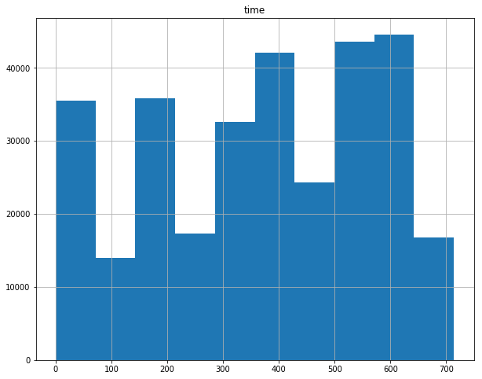

```python
transcript.hist(figsize= (10,8));
```

```python
transcript.time.value_counts()
```

```
408    17030
576    17015
504    16822
336    16302
168    16150
0      15561
414     3583
510     3514
582     3484
588     3222
516     3153
420     3146
342     3017
594     2937
426     2908
```

[output cut: 47 more lines]

```python
transcript.event.value_counts()
```

```
transaction        138953
offer received      76277
offer viewed        57725
offer completed     33579
Name: event, dtype: int64
```

*Percent of completed offers = 33579/76277 x 100 = 44.022%*

```python
transcript.value.value_counts()
```

```
{'offer id': '2298d6c36e964ae4a3e7e9706d1fb8c2'}                  14983
{'offer id': 'fafdcd668e3743c1bb461111dcafc2a4'}                  14924
{'offer id': '4d5c57ea9a6940dd891ad53e9dbe8da0'}                  14891
{'offer id': 'f19421c1d4aa40978ebb69ca19b0e20d'}                  14835
{'offer id': 'ae264e3637204a6fb9bb56bc8210ddfd'}                  14374
{'offer id': '5a8bc65990b245e5a138643cd4eb9837'}                  14305
{'offer id': '9b98b8c7a33c4b65b9aebfe6a799e6d9'}                  11848
{'offer id': '3f207df678b143eea3cee63160fa8bed'}                  11761
{'offer id': '2906b810c7d4411798c6938adc9daaa5'}                  11750
{'offer id': '0b1e1539f2cc45b7b9fa7c272da2e1d7'}                  10331
{'offer_id': 'fafdcd668e3743c1bb461111dcafc2a4', 'reward': 2}      5317
{'offer_id': '2298d6c36e964ae4a3e7e9706d1fb8c2', 'reward': 3}      5156
{'offer_id': '9b98b8c7a33c4b65b9aebfe6a799e6d9', 'reward': 5}      4354
{'offer_id': 'f19421c1d4aa40978ebb69ca19b0e20d', 'reward': 5}      4296
{'offer_id': '2906b810c7d4411798c6938adc9daaa5', 'reward': 2}      4017
{'offer_id': 'ae264e3637204a6fb9bb56bc8210ddfd', 'reward': 10}     3688
{'offer_id': '0b1e1539f2cc45b7b9fa7c272da2e1d7', 'reward': 5}      3420
{'offer_id': '4d5c57ea9a6940dd891ad53e9dbe8da0', 'reward': 10}     3331
{'amount': 0.05}                                                    431
{'amount': 0.66}                                                    166
{'amount': 1.18}                                                    165
{'amount': 1.01}                                                    163
{'amount': 1.23}                                                    161
{'amount': 0.9}                                                     161
{'amount': 0.53}                                                    159
{'amount': 0.5}                                                     159
{'amount': 1.19}                                                    159
{'amount': 0.79}                                                    157
{'amount': 1.5}                                                     156
{'amount': 0.92}                                                    156
                                                                  ...
{'amount': 49.73}                                                     1
{'amount': 749.29}                                                    1
{'amount': 83.03}                                                     1
{'amount': 51.06}                                                     1
{'amount': 53.4}                                                      1
{'amount': 47.2}                                                      1
{'amount': 1015.73}                                                   1
{'amount': 40.83}                                                     1
{'amount': 54.44}                                                     1
{'amount': 39.82}                                                     1
{'amount': 456.79}                                                    1
{'amount': 49.82}                                                     1
{'amount': 41.61}                                                     1
{'amount': 619.63}                                                    1
{'amount': 50.37}                                                     1
{'amount': 45.76}                                                     1
{'amount': 36.99}                                                     1
{'amount': 773.21}                                                    1
{'amount': 577.21}                                                    1
{'amount': 37.3}                                                      1
{'amount': 792.54}                                                    1
{'amount': 49.38}                                                     1
{'amount': 769.04}                                                    1
{'amount': 384.03}                                                    1
{'amount': 493.4}                                                     1
{'amount': 439.14}                                                    1
{'amount': 42.75}                                                     1
{'amount': 650.75}                                                    1
{'amount': 943.4}                                                     1
{'amount': 44.21}                                                     1
Name: value, Length: 5121, dtype: int64
```

*Offer_id sometimes written as "offer id". This needs standardization*

## 5. Methodology

### A. Data Preprocessing

```python
# Change 'offer id' to 'offer_id' in value column

transcript_value_list = []

for value in transcript.value.values:
    # Keys are hashable which usually implies they're immutable and can't be modified. So, we create a new key-value pair equals
    # the one we want to rename (with correct name) and delete the wrong one.
    if 'offer id' in value.keys():
        value['offer_id'] = value['offer id']
        del value['offer id']
    transcript_value_list.append(value)

transcript_value_list
```

[output not shown]

[output cut: 946 more lines]

```
 {'offer_id': '4d5c57ea9a6940dd891ad53e9dbe8da0'},
 {'offer_id': '3f207df678b143eea3cee63160fa8bed'},
 {'offer_id': '2298d6c36e964ae4a3e7e9706d1fb8c2'},
 {'offer_id': '2906b810c7d4411798c6938adc9daaa5'},
 {'offer_id': '2298d6c36e964ae4a3e7e9706d1fb8c2'},
 {'offer_id': 'fafdcd668e3743c1bb461111dcafc2a4'},
 {'offer_id': '2906b810c7d4411798c6938adc9daaa5'},
 {'offer_id': 'ae264e3637204a6fb9bb56bc8210ddfd'},
 {'offer_id': '2906b810c7d4411798c6938adc9daaa5'},
 {'offer_id': '2298d6c36e964ae4a3e7e9706d1fb8c2'},
 {'offer_id': '2906b810c7d4411798c6938adc9daaa5'},
 {'offer_id': '5a8bc65990b245e5a138643cd4eb9837'},
 {'offer_id': '9b98b8c7a33c4b65b9aebfe6a799e6d9'},
 {'offer_id': 'ae264e3637204a6fb9bb56bc8210ddfd'},
 ...]
```

```python
# Create dataframe from transcript_value_list
transcript_value = pd.DataFrame(transcript_value_list, columns = ['offer_id', 'reward', 'amount'])
transcript_value.head()
```

|  | offer_id | reward | amount |
| --- | --- | --- | --- |
| 0 | 9b98b8c7a33c4b65b9aebfe6a799e6d9 | NaN | NaN |
| 1 | 0b1e1539f2cc45b7b9fa7c272da2e1d7 | NaN | NaN |
| 2 | 2906b810c7d4411798c6938adc9daaa5 | NaN | NaN |
| 3 | fafdcd668e3743c1bb461111dcafc2a4 | NaN | NaN |
| 4 | 4d5c57ea9a6940dd891ad53e9dbe8da0 | NaN | NaN |

```python
transcript_value.info()
# offer_id values increased to 167581 instead of 134002 after changing 'offer id' to 'offer_id'
```

```
<class 'pandas.core.frame.DataFrame'>
RangeIndex: 306534 entries, 0 to 306533
Data columns (total 3 columns):
offer_id    167581 non-null object
reward      33579 non-null float64
amount      138953 non-null float64
dtypes: float64(2), object(1)
memory usage: 7.0+ MB
```

```python
# Merge transcript & transcript_value datasets using index.
new_transcript = pd.merge(transcript, transcript_value, left_index=True, right_index=True)
new_transcript.head()
```

|  | event | person | time | value | offer_id | reward | amount |
| --- | --- | --- | --- | --- | --- | --- | --- |
| 0 | offer received | 78afa995795e4d85b5d9ceeca43f5fef | 0 | {'offer_id': '9b98b8c7a33c4b65b9aebfe6a799e6d9'} | 9b98b8c7a33c4b65b9aebfe6a799e6d9 | NaN | NaN |
| 1 | offer received | a03223e636434f42ac4c3df47e8bac43 | 0 | {'offer_id': '0b1e1539f2cc45b7b9fa7c272da2e1d7'} | 0b1e1539f2cc45b7b9fa7c272da2e1d7 | NaN | NaN |
| 2 | offer received | e2127556f4f64592b11af22de27a7932 | 0 | {'offer_id': '2906b810c7d4411798c6938adc9daaa5'} | 2906b810c7d4411798c6938adc9daaa5 | NaN | NaN |
| 3 | offer received | 8ec6ce2a7e7949b1bf142def7d0e0586 | 0 | {'offer_id': 'fafdcd668e3743c1bb461111dcafc2a4'} | fafdcd668e3743c1bb461111dcafc2a4 | NaN | NaN |
| 4 | offer received | 68617ca6246f4fbc85e91a2a49552598 | 0 | {'offer_id': '4d5c57ea9a6940dd891ad53e9dbe8da0'} | 4d5c57ea9a6940dd891ad53e9dbe8da0 | NaN | NaN |

```python
new_transcript.sample(20)
```

|  | event | person | time | value | offer_id | reward | amount |
| --- | --- | --- | --- | --- | --- | --- | --- |
| 134147 | transaction | 6d43ca076aef48c3a20af0ce5cce1a52 | 354 | {'amount': 4.06} | NaN | NaN | 4.06 |
| 122122 | offer received | 8fbb14f4f4a24f2c98c1cc7672e6be2e | 336 | {'offer_id': 'f19421c1d4aa40978ebb69ca19b0e20d'} | f19421c1d4aa40978ebb69ca19b0e20d | NaN | NaN |
| 226869 | transaction | d5da09de843d412b9739c08c5bd212c7 | 522 | {'amount': 11.52} | NaN | NaN | 11.52 |
| 153421 | offer received | cdbc4f8a3ff24e5eb0dad07f9a32d11f | 408 | {'offer_id': 'f19421c1d4aa40978ebb69ca19b0e20d'} | f19421c1d4aa40978ebb69ca19b0e20d | NaN | NaN |
| 52525 | transaction | 3a3359289baf4fea995a0e9bb2972198 | 162 | {'amount': 2.87} | NaN | NaN | 2.87 |
| 9807 | offer received | f2b8206c03384a19819420abd6c80680 | 0 | {'offer_id': '9b98b8c7a33c4b65b9aebfe6a799e6d9'} | 9b98b8c7a33c4b65b9aebfe6a799e6d9 | NaN | NaN |
| 171620 | transaction | 86a32235141948dd85e67ad2a3b530c6 | 420 | {'amount': 1.34} | NaN | NaN | 1.34 |
| 14947 | transaction | 58487861a6b946d2b3c4c206ae5f0db5 | 0 | {'amount': 2.79} | NaN | NaN | 2.79 |
| 229712 | offer viewed | f55ad8ad42634441895b83676d49ba45 | 528 | {'offer_id': '9b98b8c7a33c4b65b9aebfe6a799e6d9'} | 9b98b8c7a33c4b65b9aebfe6a799e6d9 | NaN | NaN |
| 154668 | offer received | d711ee0002d943abbf0aec37ca338b1b | 408 | {'offer_id': '2906b810c7d4411798c6938adc9daaa5'} | 2906b810c7d4411798c6938adc9daaa5 | NaN | NaN |
| 11135 | offer received | 980510900b1b450fab56e15f4bf4a671 | 0 | {'offer_id': '9b98b8c7a33c4b65b9aebfe6a799e6d9'} | 9b98b8c7a33c4b65b9aebfe6a799e6d9 | NaN | NaN |
| 200163 | offer completed | 218ca70819f7456eb87f6457628bef29 | 498 | {'offer_id': 'f19421c1d4aa40978ebb69ca19b0e20d... | f19421c1d4aa40978ebb69ca19b0e20d | 5.0 | NaN |
| 110754 | transaction | f422c808ac4d47d1a65f78bab1c6ebff | 330 | {'amount': 4.96} | NaN | NaN | 4.96 |
| 99276 | transaction | 48740c646d234e87bd31148087c0eeec | 270 | {'amount': 17.34} | NaN | NaN | 17.34 |
| 41125 | transaction | d15f3f2fe6cd4f20a5da77f250cbe04b | 96 | {'amount': 20.03} | NaN | NaN | 20.03 |
| 305451 | offer completed | 21eef0356f42406c9e70c5e1c03ab378 | 714 | {'offer_id': '2906b810c7d4411798c6938adc9daaa5... | 2906b810c7d4411798c6938adc9daaa5 | 2.0 | NaN |
| 124700 | transaction | f67a8c148408430eb65beda00750a159 | 336 | {'amount': 2.5} | NaN | NaN | 2.50 |
| 95938 | offer viewed | a29ea9a53fc747dfb077c3f2ef84f83a | 252 | {'offer_id': 'ae264e3637204a6fb9bb56bc8210ddfd'} | ae264e3637204a6fb9bb56bc8210ddfd | NaN | NaN |
| 134162 | transaction | 4edd4c3dc0e64b4885e61b1d20267e67 | 354 | {'amount': 19.33} | NaN | NaN | 19.33 |
| 65207 | offer received | ae11c6794bcd4afbb6207e7f6722d93d | 168 | {'offer_id': 'f19421c1d4aa40978ebb69ca19b0e20d'} | f19421c1d4aa40978ebb69ca19b0e20d | NaN | NaN |

```python
# Merge profile & new_transcript datasets using id in profile and person in new_transcript.
profile_new_transcript = pd.merge(profile, new_transcript, left_on='id', right_on = 'person', how='left' )
profile_new_transcript.head()
```

|  | age | became_member_on | gender | id | income | event | person | time | value | offer_id | reward | amount |
| --- | --- | --- | --- | --- | --- | --- | --- | --- | --- | --- | --- | --- |
| 0 | 118 | 20170212 | None | 68be06ca386d4c31939f3a4f0e3dd783 | NaN | offer received | 68be06ca386d4c31939f3a4f0e3dd783 | 168 | {'offer_id': '2906b810c7d4411798c6938adc9daaa5'} | 2906b810c7d4411798c6938adc9daaa5 | NaN | NaN |
| 1 | 118 | 20170212 | None | 68be06ca386d4c31939f3a4f0e3dd783 | NaN | offer viewed | 68be06ca386d4c31939f3a4f0e3dd783 | 216 | {'offer_id': '2906b810c7d4411798c6938adc9daaa5'} | 2906b810c7d4411798c6938adc9daaa5 | NaN | NaN |
| 2 | 118 | 20170212 | None | 68be06ca386d4c31939f3a4f0e3dd783 | NaN | offer received | 68be06ca386d4c31939f3a4f0e3dd783 | 336 | {'offer_id': '0b1e1539f2cc45b7b9fa7c272da2e1d7'} | 0b1e1539f2cc45b7b9fa7c272da2e1d7 | NaN | NaN |
| 3 | 118 | 20170212 | None | 68be06ca386d4c31939f3a4f0e3dd783 | NaN | offer viewed | 68be06ca386d4c31939f3a4f0e3dd783 | 348 | {'offer_id': '0b1e1539f2cc45b7b9fa7c272da2e1d7'} | 0b1e1539f2cc45b7b9fa7c272da2e1d7 | NaN | NaN |
| 4 | 118 | 20170212 | None | 68be06ca386d4c31939f3a4f0e3dd783 | NaN | transaction | 68be06ca386d4c31939f3a4f0e3dd783 | 360 | {'amount': 0.35000000000000003} | NaN | NaN | 0.35 |

```python
profile_new_transcript.shape
```

```
(306534, 12)
```

```python
transcript.loc[(transcript.person == '68be06ca386d4c31939f3a4f0e3dd783'), 'value']
```

```
53174      {'offer_id': '2906b810c7d4411798c6938adc9daaa5'}
85290      {'offer_id': '2906b810c7d4411798c6938adc9daaa5'}
110828     {'offer_id': '0b1e1539f2cc45b7b9fa7c272da2e1d7'}
130147     {'offer_id': '0b1e1539f2cc45b7b9fa7c272da2e1d7'}
135224                      {'amount': 0.35000000000000003}
150596     {'offer_id': 'fafdcd668e3743c1bb461111dcafc2a4'}
163374     {'offer_id': 'fafdcd668e3743c1bb461111dcafc2a4'}
167626                                     {'amount': 0.74}
182544                       {'amount': 1.8900000000000001}
201570     {'offer_id': '2298d6c36e964ae4a3e7e9706d1fb8c2'}
214274     {'offer_id': '2298d6c36e964ae4a3e7e9706d1fb8c2'}
218392                                     {'amount': 5.04}
230411                                     {'amount': 0.38}
237364                                     {'amount': 2.12}
237365    {'offer_id': 'fafdcd668e3743c1bb461111dcafc2a4...
237366    {'offer_id': '2298d6c36e964ae4a3e7e9706d1fb8c2...
245122     {'offer_id': 'fafdcd668e3743c1bb461111dcafc2a4'}
262137     {'offer_id': 'fafdcd668e3743c1bb461111dcafc2a4'}
274519                                     {'amount': 4.61}
283959                                     {'amount': 0.06}
301915                                     {'amount': 5.21}
Name: value, dtype: object
```

```python
transcript.loc[(transcript.person == '68be06ca386d4c31939f3a4f0e3dd783'), 'event']
```

```
53174      offer received
85290        offer viewed
110828     offer received
130147       offer viewed
135224        transaction
150596     offer received
163374       offer viewed
167626        transaction
182544        transaction
201570     offer received
214274       offer viewed
218392        transaction
230411        transaction
237364        transaction
237365    offer completed
237366    offer completed
245122     offer received
262137       offer viewed
274519        transaction
283959        transaction
301915        transaction
Name: event, dtype: object
```

```python
#Drop rows with no demographic values as they will not give us any insights after analysis even if they have made purchases.
no_nan = profile_new_transcript.dropna(subset=['gender'])
no_nan.head()
```

|  | age | became_member_on | gender | id | income | event | person | time | value | offer_id | reward | amount |
| --- | --- | --- | --- | --- | --- | --- | --- | --- | --- | --- | --- | --- |
| 21 | 55 | 20170715 | F | 0610b486422d4921ae7d2bf64640c50b | 112000.0 | transaction | 0610b486422d4921ae7d2bf64640c50b | 18 | {'amount': 21.51} | NaN | NaN | 21.51 |
| 22 | 55 | 20170715 | F | 0610b486422d4921ae7d2bf64640c50b | 112000.0 | transaction | 0610b486422d4921ae7d2bf64640c50b | 144 | {'amount': 32.28} | NaN | NaN | 32.28 |
| 23 | 55 | 20170715 | F | 0610b486422d4921ae7d2bf64640c50b | 112000.0 | offer received | 0610b486422d4921ae7d2bf64640c50b | 408 | {'offer_id': '9b98b8c7a33c4b65b9aebfe6a799e6d9'} | 9b98b8c7a33c4b65b9aebfe6a799e6d9 | NaN | NaN |
| 24 | 55 | 20170715 | F | 0610b486422d4921ae7d2bf64640c50b | 112000.0 | offer received | 0610b486422d4921ae7d2bf64640c50b | 504 | {'offer_id': '3f207df678b143eea3cee63160fa8bed'} | 3f207df678b143eea3cee63160fa8bed | NaN | NaN |
| 25 | 55 | 20170715 | F | 0610b486422d4921ae7d2bf64640c50b | 112000.0 | transaction | 0610b486422d4921ae7d2bf64640c50b | 528 | {'amount': 23.22} | NaN | NaN | 23.22 |

```python
# Merge no_nan & portfolio datasets using offer_id in id and person in portfolio.
new_df = pd.merge(no_nan, portfolio, left_on='offer_id', right_on = 'id', how='left' )
new_df.head()
# Need to rename reward_x & reward_y
```

|  | age | became_member_on | gender | id_x | income | event | person | time | value | offer_id | reward_x | amount | channels | difficulty | duration | id_y | offer_type | reward_y |
| --- | --- | --- | --- | --- | --- | --- | --- | --- | --- | --- | --- | --- | --- | --- | --- | --- | --- | --- |
| 0 | 55 | 20170715 | F | 0610b486422d4921ae7d2bf64640c50b | 112000.0 | transaction | 0610b486422d4921ae7d2bf64640c50b | 18 | {'amount': 21.51} | NaN | NaN | 21.51 | NaN | NaN | NaN | NaN | NaN | NaN |
| 1 | 55 | 20170715 | F | 0610b486422d4921ae7d2bf64640c50b | 112000.0 | transaction | 0610b486422d4921ae7d2bf64640c50b | 144 | {'amount': 32.28} | NaN | NaN | 32.28 | NaN | NaN | NaN | NaN | NaN | NaN |
| 2 | 55 | 20170715 | F | 0610b486422d4921ae7d2bf64640c50b | 112000.0 | offer received | 0610b486422d4921ae7d2bf64640c50b | 408 | {'offer_id': '9b98b8c7a33c4b65b9aebfe6a799e6d9'} | 9b98b8c7a33c4b65b9aebfe6a799e6d9 | NaN | NaN | [web, email, mobile] | 5.0 | 7.0 | 9b98b8c7a33c4b65b9aebfe6a799e6d9 | bogo | 5.0 |
| 3 | 55 | 20170715 | F | 0610b486422d4921ae7d2bf64640c50b | 112000.0 | offer received | 0610b486422d4921ae7d2bf64640c50b | 504 | {'offer_id': '3f207df678b143eea3cee63160fa8bed'} | 3f207df678b143eea3cee63160fa8bed | NaN | NaN | [web, email, mobile] | 0.0 | 4.0 | 3f207df678b143eea3cee63160fa8bed | informational | 0.0 |
| 4 | 55 | 20170715 | F | 0610b486422d4921ae7d2bf64640c50b | 112000.0 | transaction | 0610b486422d4921ae7d2bf64640c50b | 528 | {'amount': 23.22} | NaN | NaN | 23.22 | NaN | NaN | NaN | NaN | NaN | NaN |

```python
# Drop person's id (id_x) since it's no longer needed as "person" column replaced it.
# Drop value since it's been extracted into separate columns.
# Drop id_y since it's the same as offer id.
final_df = new_df.drop(columns=['id_x', 'value', 'id_y'])
# Rename columns
final_df = final_df.rename(columns = {'reward_x':'earned_reward', 'reward_y': 'offer_reward',
                                      'time':'event_time', 'duration': 'offer_duration'})
final_df.head(10)
```

|  | age | became_member_on | gender | income | event | person | event_time | offer_id | earned_reward | amount | channels | difficulty | offer_duration | offer_type | offer_reward |
| --- | --- | --- | --- | --- | --- | --- | --- | --- | --- | --- | --- | --- | --- | --- | --- |
| 0 | 55 | 20170715 | F | 112000.0 | transaction | 0610b486422d4921ae7d2bf64640c50b | 18 | NaN | NaN | 21.51 | NaN | NaN | NaN | NaN | NaN |
| 1 | 55 | 20170715 | F | 112000.0 | transaction | 0610b486422d4921ae7d2bf64640c50b | 144 | NaN | NaN | 32.28 | NaN | NaN | NaN | NaN | NaN |
| 2 | 55 | 20170715 | F | 112000.0 | offer received | 0610b486422d4921ae7d2bf64640c50b | 408 | 9b98b8c7a33c4b65b9aebfe6a799e6d9 | NaN | NaN | [web, email, mobile] | 5.0 | 7.0 | bogo | 5.0 |
| 3 | 55 | 20170715 | F | 112000.0 | offer received | 0610b486422d4921ae7d2bf64640c50b | 504 | 3f207df678b143eea3cee63160fa8bed | NaN | NaN | [web, email, mobile] | 0.0 | 4.0 | informational | 0.0 |
| 4 | 55 | 20170715 | F | 112000.0 | transaction | 0610b486422d4921ae7d2bf64640c50b | 528 | NaN | NaN | 23.22 | NaN | NaN | NaN | NaN | NaN |
| 5 | 55 | 20170715 | F | 112000.0 | offer completed | 0610b486422d4921ae7d2bf64640c50b | 528 | 9b98b8c7a33c4b65b9aebfe6a799e6d9 | 5.0 | NaN | [web, email, mobile] | 5.0 | 7.0 | bogo | 5.0 |
| 6 | 75 | 20170509 | F | 100000.0 | offer received | 78afa995795e4d85b5d9ceeca43f5fef | 0 | 9b98b8c7a33c4b65b9aebfe6a799e6d9 | NaN | NaN | [web, email, mobile] | 5.0 | 7.0 | bogo | 5.0 |
| 7 | 75 | 20170509 | F | 100000.0 | offer viewed | 78afa995795e4d85b5d9ceeca43f5fef | 6 | 9b98b8c7a33c4b65b9aebfe6a799e6d9 | NaN | NaN | [web, email, mobile] | 5.0 | 7.0 | bogo | 5.0 |
| 8 | 75 | 20170509 | F | 100000.0 | transaction | 78afa995795e4d85b5d9ceeca43f5fef | 132 | NaN | NaN | 19.89 | NaN | NaN | NaN | NaN | NaN |
| 9 | 75 | 20170509 | F | 100000.0 | offer completed | 78afa995795e4d85b5d9ceeca43f5fef | 132 | 9b98b8c7a33c4b65b9aebfe6a799e6d9 | 5.0 | NaN | [web, email, mobile] | 5.0 | 7.0 | bogo | 5.0 |

```python
# Re-arrange columns
final_df = final_df[['person', 'age', 'gender', 'income','became_member_on', 'event', 'event_time', 'offer_type',
                     'offer_reward', 'earned_reward', 'amount','offer_id', 'channels', 'difficulty', 'offer_duration']]
final_df.head(10)
```

|  | person | age | gender | income | became_member_on | event | event_time | offer_type | offer_reward | earned_reward | amount | offer_id | channels | difficulty | offer_duration |
| --- | --- | --- | --- | --- | --- | --- | --- | --- | --- | --- | --- | --- | --- | --- | --- |
| 0 | 0610b486422d4921ae7d2bf64640c50b | 55 | F | 112000.0 | 20170715 | transaction | 18 | NaN | NaN | NaN | 21.51 | NaN | NaN | NaN | NaN |
| 1 | 0610b486422d4921ae7d2bf64640c50b | 55 | F | 112000.0 | 20170715 | transaction | 144 | NaN | NaN | NaN | 32.28 | NaN | NaN | NaN | NaN |
| 2 | 0610b486422d4921ae7d2bf64640c50b | 55 | F | 112000.0 | 20170715 | offer received | 408 | bogo | 5.0 | NaN | NaN | 9b98b8c7a33c4b65b9aebfe6a799e6d9 | [web, email, mobile] | 5.0 | 7.0 |
| 3 | 0610b486422d4921ae7d2bf64640c50b | 55 | F | 112000.0 | 20170715 | offer received | 504 | informational | 0.0 | NaN | NaN | 3f207df678b143eea3cee63160fa8bed | [web, email, mobile] | 0.0 | 4.0 |
| 4 | 0610b486422d4921ae7d2bf64640c50b | 55 | F | 112000.0 | 20170715 | transaction | 528 | NaN | NaN | NaN | 23.22 | NaN | NaN | NaN | NaN |
| 5 | 0610b486422d4921ae7d2bf64640c50b | 55 | F | 112000.0 | 20170715 | offer completed | 528 | bogo | 5.0 | 5.0 | NaN | 9b98b8c7a33c4b65b9aebfe6a799e6d9 | [web, email, mobile] | 5.0 | 7.0 |
| 6 | 78afa995795e4d85b5d9ceeca43f5fef | 75 | F | 100000.0 | 20170509 | offer received | 0 | bogo | 5.0 | NaN | NaN | 9b98b8c7a33c4b65b9aebfe6a799e6d9 | [web, email, mobile] | 5.0 | 7.0 |
| 7 | 78afa995795e4d85b5d9ceeca43f5fef | 75 | F | 100000.0 | 20170509 | offer viewed | 6 | bogo | 5.0 | NaN | NaN | 9b98b8c7a33c4b65b9aebfe6a799e6d9 | [web, email, mobile] | 5.0 | 7.0 |
| 8 | 78afa995795e4d85b5d9ceeca43f5fef | 75 | F | 100000.0 | 20170509 | transaction | 132 | NaN | NaN | NaN | 19.89 | NaN | NaN | NaN | NaN |
| 9 | 78afa995795e4d85b5d9ceeca43f5fef | 75 | F | 100000.0 | 20170509 | offer completed | 132 | bogo | 5.0 | 5.0 | NaN | 9b98b8c7a33c4b65b9aebfe6a799e6d9 | [web, email, mobile] | 5.0 | 7.0 |

```python
final_df.shape
```

```
(272762, 15)
```

```python
final_df.describe()
```

|  | age | income | became_member_on | event_time | offer_reward | earned_reward | amount | difficulty | offer_duration |
| --- | --- | --- | --- | --- | --- | --- | --- | --- | --- |
| count | 272762.000000 | 272762.000000 | 2.727620e+05 | 272762.000000 | 148805.000000 | 32444.000000 | 123957.000000 | 148805.000000 | 148805.000000 |
| mean | 53.840696 | 64337.000755 | 2.016526e+07 | 366.707694 | 4.442445 | 4.948249 | 13.996325 | 7.890561 | 6.625207 |
| std | 17.551337 | 21243.762941 | 1.209695e+04 | 200.359087 | 3.372362 | 2.905376 | 31.749420 | 5.041335 | 2.133035 |
| min | 18.000000 | 30000.000000 | 2.013073e+07 | 0.000000 | 0.000000 | 2.000000 | 0.050000 | 0.000000 | 3.000000 |
| 25% | 41.000000 | 48000.000000 | 2.016032e+07 | 186.000000 | 2.000000 | 2.000000 | 3.660000 | 5.000000 | 5.000000 |
| 50% | 55.000000 | 62000.000000 | 2.017041e+07 | 408.000000 | 5.000000 | 5.000000 | 10.800000 | 10.000000 | 7.000000 |
| 75% | 66.000000 | 78000.000000 | 2.017113e+07 | 528.000000 | 5.000000 | 5.000000 | 19.130000 | 10.000000 | 7.000000 |
| max | 101.000000 | 120000.000000 | 2.018073e+07 | 714.000000 | 10.000000 | 10.000000 | 1062.280000 | 20.000000 | 10.000000 |

### B. Storing Data

```python
final_df.to_csv('final_df.csv')
```

### C. Implementation

```python
# Create Age_bins column in the dataframe
final_df['age_bins'] = pd.qcut(final_df['age'], q=10, precision=0)

# Create dataframe subsets 'offer received', 'offer viewed', 'offer completed', 'transaction' to facilitate recall & comparison
offer_received = final_df[final_df.event == 'offer received']
offer_viewed = final_df[final_df.event == 'offer viewed']
offer_completed = final_df[final_df.event == 'offer completed']
transaction = final_df[final_df.event == 'transaction']

# Create dataframe subsets 'males'and 'females' from  offer_completed to facilitate recall and comparison
males = offer_completed[offer_completed.gender == 'M']
females = offer_completed[offer_completed.gender == 'F']
```

```python
# View Age_bins
final_df.age_bins.value_counts().sort_index()
```

```
(17.0, 28.0]     28473
(28.0, 38.0]     28978
(38.0, 45.0]     27243
(45.0, 51.0]     30589
(51.0, 55.0]     25862
(55.0, 59.0]     26273
(59.0, 64.0]     28908
(64.0, 69.0]     25018
(69.0, 76.0]     24520
(76.0, 101.0]    26898
Name: age_bins, dtype: int64
```

#### 1- Correlation between income and purchase

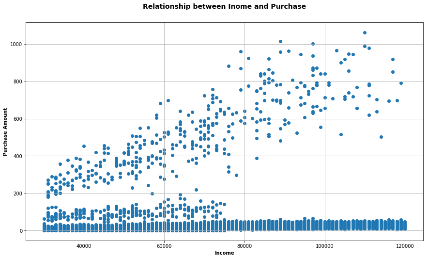

```python
#scatter plot between income and purchase
plt.figure(figsize=[14.70, 8.27])
plt.scatter(transaction.income, transaction.amount)
plt.title('Relationship between Inome and Purchase', y=1.05, fontsize=14, fontweight='bold')
plt.xlabel('Income', fontweight='bold')
plt.ylabel('Purchase Amount', fontweight='bold')
plt.grid();
```

*Although there is a direct correlation between customer income and their purchase amount, it seems there is a group of people whose purchase amount is constant whaatever their income is. Hmm.. Interesting!*

*I believe Starbucks need to dig deeper into this to find what traits those customers have.*

*Meanwhile, the company should target high income customers as they are willing to pay more.*

#### 2- Purchases by demographic groups

```python
# Amount spent by gender
amount_by_gender = dict(final_df.groupby('gender')['amount'].sum())
amount_by_gender
```

```
{'F': 863695.00000001106, 'M': 844890.85999999952, 'O': 26356.540000000001}
```

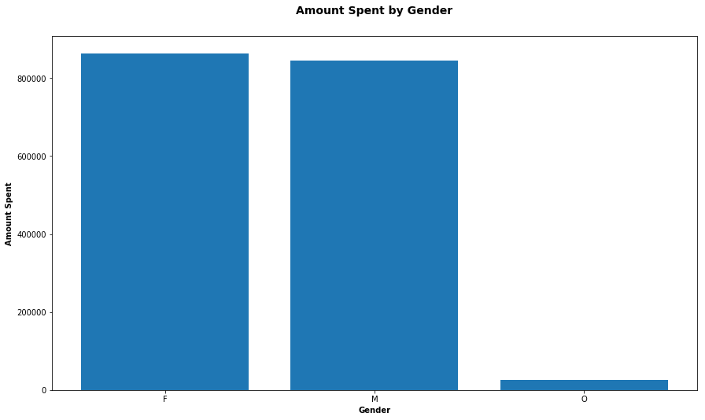

```python
# Plot Amount spent by gender
plt.figure(figsize=[14.70, 8.27])
plt.bar(amount_by_gender.keys(), amount_by_gender.values())
plt.title('Amount Spent by Gender', y=1.05, fontsize=14, fontweight='bold')
plt.xlabel('Gender', fontweight='bold')
plt.ylabel('Amount Spent', fontweight='bold');
```

*Females spend the most (863695), but are very close to males (844890).*

*Other gender doesn't have significant influence on analysis results and can be neglected through the whole analysis process.*

```python
# Amount spent by age
amount_by_age = dict(final_df.groupby("age")["amount"].sum())
amount_by_age
```

```
{18: 5632.5700000000061,
 19: 9705.1199999999826,
 20: 10379.900000000014,
 21: 13838.490000000003,
 22: 12337.020000000015,
 23: 9818.480000000005,
 24: 11760.800000000016,
 25: 11936.839999999997,
 26: 12718.039999999975,
 27: 10273.130000000012,
 28: 12160.999999999989,
 29: 11758.429999999989,
 30: 12645.009999999987,
 31: 8007.0300000000061,
 32: 13691.470000000036,
```

[output cut: 69 more lines]

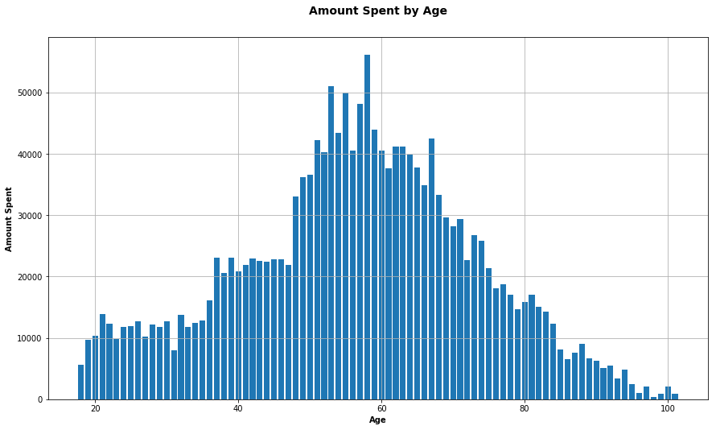

```python
# Plot Amount spent by age
plt.figure(figsize=[14.70, 8.27])
plt.bar(amount_by_age.keys(), amount_by_age.values())
plt.title('Amount Spent by Age', y=1.05, fontsize=14, fontweight='bold')
plt.xlabel('Age', fontweight='bold')
plt.ylabel('Amount Spent', fontweight='bold')
plt.grid();
```

*The amount spent corresponds to age distribution. Customers between 50 & 70 years spend the most.*

```python
final_df.amount.sum()
```

```
1734942.3999999999
```

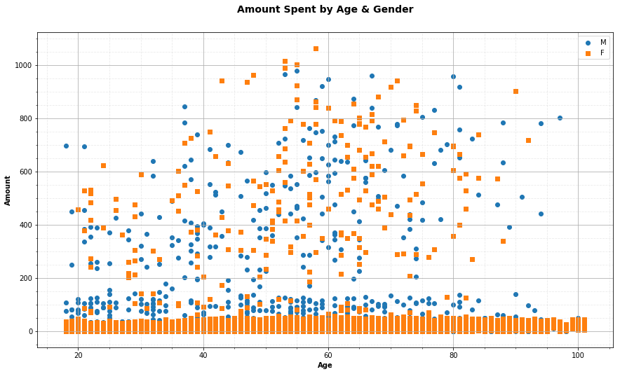

```python
# Plot Amount spent by age & gender
plt.figure(figsize=[14.70, 8.27])

cat_markers = [['M', 'o'],
               ['F', 's']]

for cat, marker in cat_markers:
    df_cat = final_df[final_df['gender'] == cat]
    plt.scatter(data = df_cat, x = 'age', y = 'amount', marker = marker)

plt.title('Amount Spent by Age & Gender', y=1.05, fontsize=14, fontweight='bold')
plt.xlabel('Age', fontweight='bold')
plt.ylabel('Amount', fontweight='bold')
plt.legend(['M','F'])
plt.grid()
plt.minorticks_on()
plt.grid(b=True, which='minor', color='#999999', linestyle='--', alpha=0.2);
```

*Females of age 43-58 spend the most, males of age 53-80 spend the most*

### C. Refinement

A combination of age and gender is used to classify customers into more specific groups so that their response to different offer types can be measured more accurately, not just the purchases they made.Thus, can determine which demographic groups respond best to which offer type.

```python
offer_received.count()
```

```
person              66501
age                 66501
gender              66501
income              66501
became_member_on    66501
event               66501
event_time          66501
offer_type          66501
offer_reward        66501
earned_reward           0
amount                  0
offer_id            66501
channels            66501
difficulty          66501
offer_duration      66501
age_bins            66501
dtype: int64
```

*66501 clients of known demographics received offers.*

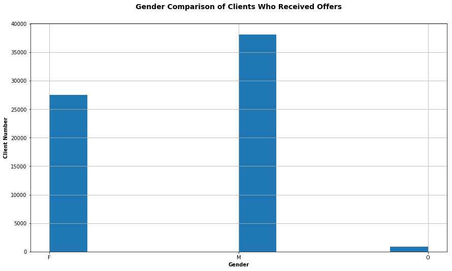

```python
# Compare genders of those who received offers.
plt.figure(figsize=[14.70, 8.27])
offer_received.gender.hist()
plt.title('Gender Comparison of Clients Who Received Offers', y=1.05, fontsize=14, fontweight='bold')
plt.xlabel('Gender', fontweight='bold')
plt.ylabel('Client Number', fontweight='bold');
```

```python
offer_received.gender.value_counts()
```

```
M    38129
F    27456
O      916
Name: gender, dtype: int64
```

```python
offer_received.groupby(['gender', 'offer_type']).count()
```

| gender | offer_type | person | age | income | became_member_on | event | event_time | offer_reward | earned_reward | amount | offer_id | channels | difficulty | offer_duration | age_bins |
| --- | --- | --- | --- | --- | --- | --- | --- | --- | --- | --- | --- | --- | --- | --- | --- |
| F | bogo | 10975 | 10975 | 10975 | 10975 | 10975 | 10975 | 10975 | 0 | 0 | 10975 | 10975 | 10975 | 10975 | 10975 |
|  | discount | 10943 | 10943 | 10943 | 10943 | 10943 | 10943 | 10943 | 0 | 0 | 10943 | 10943 | 10943 | 10943 | 10943 |
|  | informational | 5538 | 5538 | 5538 | 5538 | 5538 | 5538 | 5538 | 0 | 0 | 5538 | 5538 | 5538 | 5538 | 5538 |
| M | bogo | 15208 | 15208 | 15208 | 15208 | 15208 | 15208 | 15208 | 0 | 0 | 15208 | 15208 | 15208 | 15208 | 15208 |
|  | discount | 15354 | 15354 | 15354 | 15354 | 15354 | 15354 | 15354 | 0 | 0 | 15354 | 15354 | 15354 | 15354 | 15354 |
|  | informational | 7567 | 7567 | 7567 | 7567 | 7567 | 7567 | 7567 | 0 | 0 | 7567 | 7567 | 7567 | 7567 | 7567 |
| O | bogo | 354 | 354 | 354 | 354 | 354 | 354 | 354 | 0 | 0 | 354 | 354 | 354 | 354 | 354 |
|  | discount | 367 | 367 | 367 | 367 | 367 | 367 | 367 | 0 | 0 | 367 | 367 | 367 | 367 | 367 |
|  | informational | 195 | 195 | 195 | 195 | 195 | 195 | 195 | 0 | 0 | 195 | 195 | 195 | 195 | 195 |

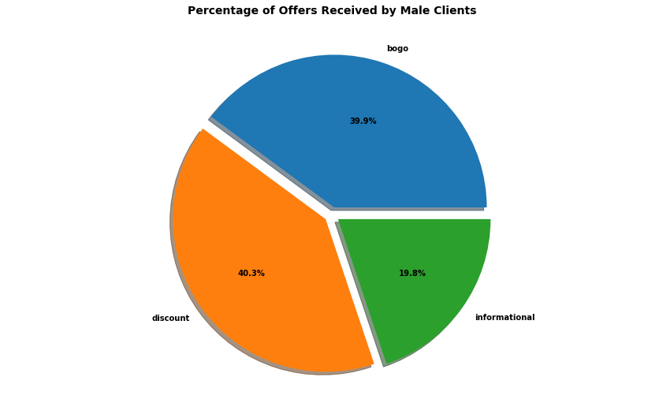

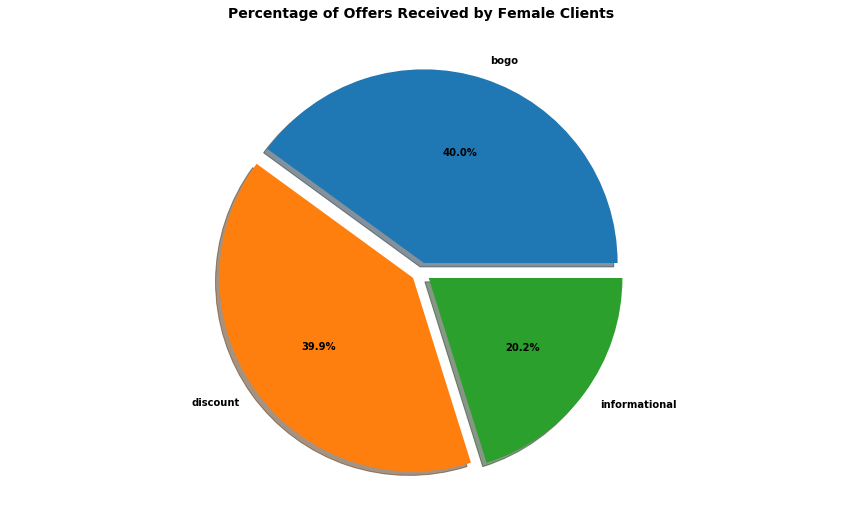

```python
# Creating a pie chart of offers received by male clients
plt.figure(figsize=[14.7,  8.27])
plt.pie(offer_received.groupby(['gender', 'offer_type']).count()[3:6].person,
       labels = ['bogo', 'discount', 'informational'],
       autopct = '%1.1f%%', # To show percent on plot. 1.1  formats the percentage to the tenth place.
       shadow=True,
       explode=(0.05, 0.05, 0.05),
       textprops={'fontweight': 'bold'}
       )
plt.title('Percentage of Offers Received by Male Clients', y=1.05, fontsize=14, fontweight='bold')
plt.axis('equal'); # By default, matplotlib creates pie charts with a tilt. This line remove this tilt

# Create a pie chart of offers received by female clients
plt.figure(figsize=[14.7,  8.27])
plt.pie(offer_received.groupby(['gender', 'offer_type']).count()[:3].person,
       labels = ['bogo', 'discount', 'informational'],
       autopct = '%1.1f%%',
       shadow=True,
       explode=(0.05, 0.05, 0.05),
       textprops={'fontweight': 'bold'}
       )
plt.title('Percentage of Offers Received by Female Clients', y=1.05, fontsize=14, fontweight='bold')
plt.axis('equal');
```

*Almost the same percent of offer types was received by both males and females*

```python
offer_viewed.count()
```

```
person              49860
age                 49860
gender              49860
income              49860
became_member_on    49860
event               49860
event_time          49860
offer_type          49860
offer_reward        49860
earned_reward           0
amount                  0
offer_id            49860
channels            49860
difficulty          49860
offer_duration      49860
age_bins            49860
dtype: int64
```

*Only 49860 of clients who received offers viewed them. That's 74.9%*

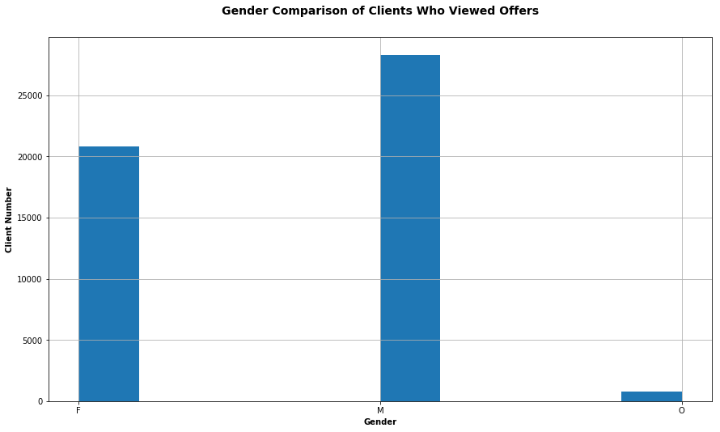

```python
# Compare genders of those who viewed offers.
plt.figure(figsize=[14.70, 8.27])
offer_viewed.gender.hist()
plt.legend()
plt.title('Gender Comparison of Clients Who Viewed Offers', y=1.05, fontsize=14, fontweight='bold')
plt.xlabel('Gender', fontweight='bold')
plt.ylabel('Client Number', fontweight='bold');
```

```python
offer_viewed.gender.value_counts()
```

```
M    28301
F    20786
O      773
Name: gender, dtype: int64
```

```python
offer_viewed.groupby(['gender', 'offer_type']).count()
```

| gender | offer_type | person | age | income | became_member_on | event | event_time | offer_reward | earned_reward | amount | offer_id | channels | difficulty | offer_duration | age_bins |
| --- | --- | --- | --- | --- | --- | --- | --- | --- | --- | --- | --- | --- | --- | --- | --- |
| F | bogo | 9143 | 9143 | 9143 | 9143 | 9143 | 9143 | 9143 | 0 | 0 | 9143 | 9143 | 9143 | 9143 | 9143 |
|  | discount | 7733 | 7733 | 7733 | 7733 | 7733 | 7733 | 7733 | 0 | 0 | 7733 | 7733 | 7733 | 7733 | 7733 |
|  | informational | 3910 | 3910 | 3910 | 3910 | 3910 | 3910 | 3910 | 0 | 0 | 3910 | 3910 | 3910 | 3910 | 3910 |
| M | bogo | 12581 | 12581 | 12581 | 12581 | 12581 | 12581 | 12581 | 0 | 0 | 12581 | 12581 | 12581 | 12581 | 12581 |
|  | discount | 10431 | 10431 | 10431 | 10431 | 10431 | 10431 | 10431 | 0 | 0 | 10431 | 10431 | 10431 | 10431 | 10431 |
|  | informational | 5289 | 5289 | 5289 | 5289 | 5289 | 5289 | 5289 | 0 | 0 | 5289 | 5289 | 5289 | 5289 | 5289 |
| O | bogo | 315 | 315 | 315 | 315 | 315 | 315 | 315 | 0 | 0 | 315 | 315 | 315 | 315 | 315 |
|  | discount | 297 | 297 | 297 | 297 | 297 | 297 | 297 | 0 | 0 | 297 | 297 | 297 | 297 | 297 |
|  | informational | 161 | 161 | 161 | 161 | 161 | 161 | 161 | 0 | 0 | 161 | 161 | 161 | 161 | 161 |

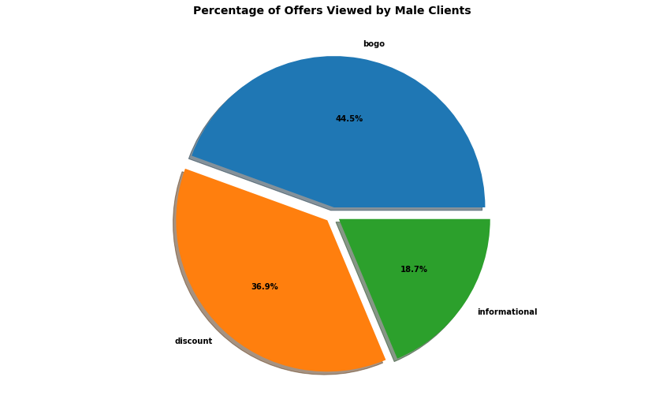

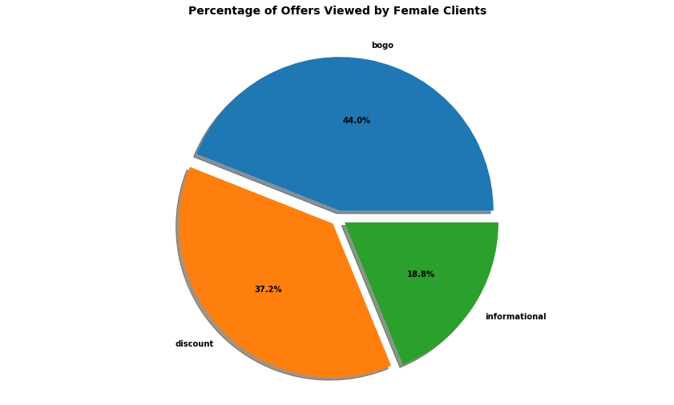

```python
# Create a pie chart of offers viewed by male clients
plt.figure(figsize=[14.7,  8.27])
plt.pie(offer_viewed.groupby(['gender', 'offer_type']).count()[3:6].person,
       labels = ['bogo', 'discount', 'informational'],
       autopct = '%1.1f%%',
       shadow=True,
       explode=(0.05, 0.05, 0.05),
       textprops={'fontweight': 'bold'}
       )
plt.title('Percentage of Offers Viewed by Male Clients', y=1.05, fontsize=14, fontweight='bold')
plt.axis('equal');

# Create a pie chart of offers viewed by female clients
plt.figure(figsize=[14.7,  8.27])
plt.pie(offer_viewed.groupby(['gender', 'offer_type']).count()[:3].person,
       labels = ['bogo', 'discount', 'informational'],
       autopct = '%1.1f%%',
       shadow=True,
       explode=(0.05, 0.05, 0.05),
       textprops={'fontweight': 'bold'}
       )
plt.title('Percentage of Offers Viewed by Female Clients', y=1.05, fontsize=14, fontweight='bold')
plt.axis('equal');
```

*Almost the same percent of offer types was viewed by both males and females*

```python
offer_completed.count()
```

```
person              32444
age                 32444
gender              32444
income              32444
became_member_on    32444
event               32444
event_time          32444
offer_type          32444
offer_reward        32444
earned_reward       32444
amount                  0
offer_id            32444
channels            32444
difficulty          32444
offer_duration      32444
age_bins            32444
dtype: int64
```

*Only 32444 of the received offers were completed. That's 48.79%*

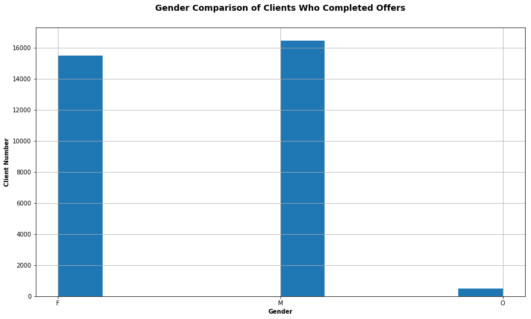

```python
# Compare genders of those who completed offers.
plt.figure(figsize=[14.70, 8.27])
offer_completed.gender.hist()
plt.legend()
plt.title('Gender Comparison of Clients Who Completed Offers', y=1.05, fontsize=14, fontweight='bold')
plt.xlabel('Gender', fontweight='bold')
plt.ylabel('Client Number', fontweight='bold');
```

```python
offer_completed.gender.value_counts()
```

```
M    16466
F    15477
O      501
Name: gender, dtype: int64
```

```python
print ('Percent of females who completed offers of those who received offers = ', offer_completed.gender.value_counts()[1]/
offer_received.gender.value_counts()[1]*100, '%')
```

```
Percent of females who completed offers of those who received offers =  56.3701923077 %
```

```python
print ('Percent of males who completed offers of those who received offers = ', offer_completed.gender.value_counts()[0]/
offer_received.gender.value_counts()[0]*100, '%')
```

```
Percent of males who completed offers of those who received offers =  43.1849773139 %
```

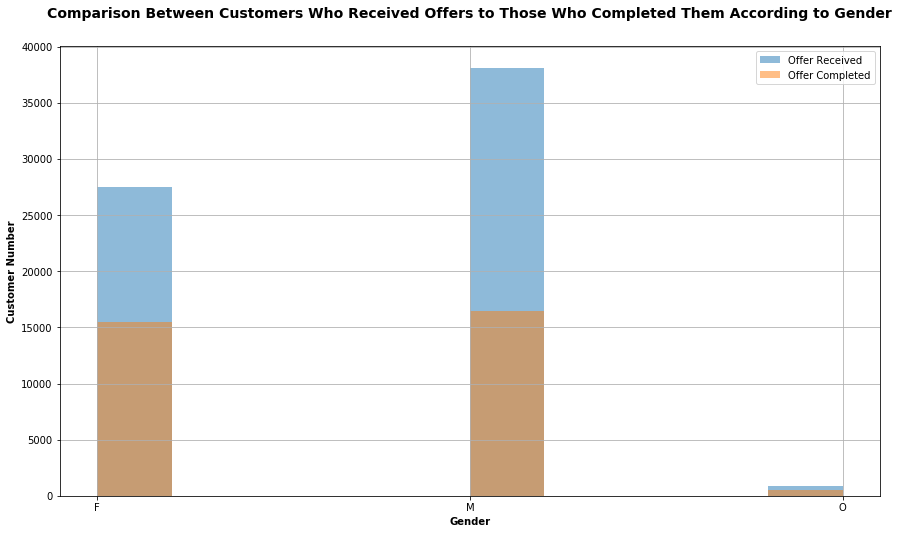

```python
# Compare genders of those who received offers to those who completed them.
plt.figure(figsize=[14.70, 8.27])
offer_received.gender.hist(alpha = 0.5, label = 'Offer Received')
offer_completed.gender.hist(alpha = 0.5, label = 'Offer Completed')
plt.legend()
plt.title('Comparison Between Customers Who Received Offers to Those Who Completed Them According to Gender',
          y=1.05, fontsize=14, fontweight='bold')
plt.xlabel('Gender', fontweight='bold')
plt.ylabel('Customer Number', fontweight='bold');
```

*Number of male customers who received, viewed, and completed offers is more than females.*

*Number of female customers who completed offers is very close to male customers*

*Percent of females who completed offers is higher than that of males. Therefore the company should focus on sending more offers to females.*

```python
offer_completed.groupby(['gender', 'offer_type']).count()
```

| gender | offer_type | person | age | income | became_member_on | event | event_time | offer_reward | earned_reward | amount | offer_id | channels | difficulty | offer_duration | age_bins |
| --- | --- | --- | --- | --- | --- | --- | --- | --- | --- | --- | --- | --- | --- | --- | --- |
| F | bogo | 7501 | 7501 | 7501 | 7501 | 7501 | 7501 | 7501 | 7501 | 0 | 7501 | 7501 | 7501 | 7501 | 7501 |
|  | discount | 7976 | 7976 | 7976 | 7976 | 7976 | 7976 | 7976 | 7976 | 0 | 7976 | 7976 | 7976 | 7976 | 7976 |
| M | bogo | 7512 | 7512 | 7512 | 7512 | 7512 | 7512 | 7512 | 7512 | 0 | 7512 | 7512 | 7512 | 7512 | 7512 |
|  | discount | 8954 | 8954 | 8954 | 8954 | 8954 | 8954 | 8954 | 8954 | 0 | 8954 | 8954 | 8954 | 8954 | 8954 |
| O | bogo | 245 | 245 | 245 | 245 | 245 | 245 | 245 | 245 | 0 | 245 | 245 | 245 | 245 | 245 |
|  | discount | 256 | 256 | 256 | 256 | 256 | 256 | 256 | 256 | 0 | 256 | 256 | 256 | 256 | 256 |

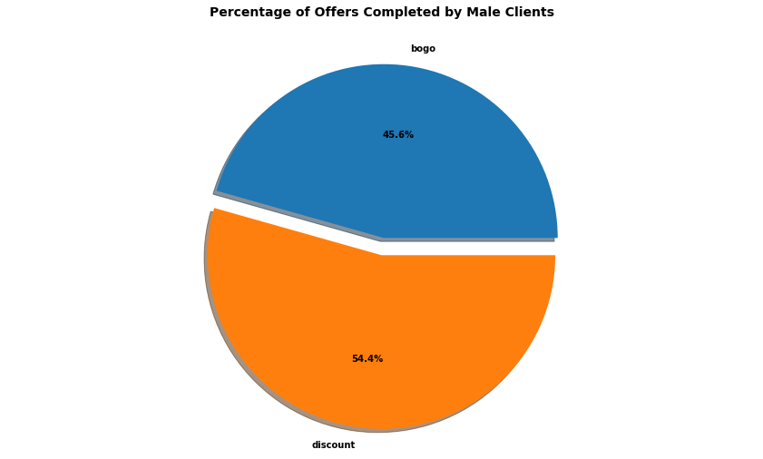

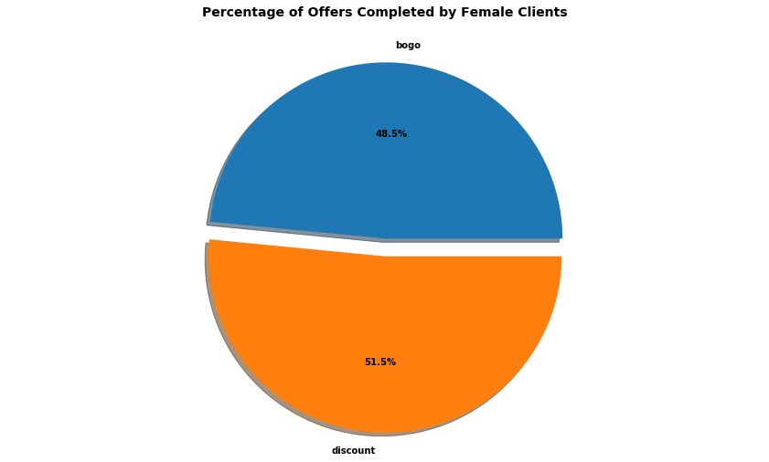

```python
# Creating a pie chart of offers completed by male clients
plt.figure(figsize=[14.7,  8.27])
plt.pie(offer_completed.groupby(['gender', 'offer_type']).count()[2:4].person,
       labels = ['bogo', 'discount'],
       autopct = '%1.1f%%',
       shadow=True,
       explode=(0.05, 0.05),
       textprops={'fontweight': 'bold'}
       )
plt.title('Percentage of Offers Completed by Male Clients', y=1.05, fontsize=14, fontweight='bold')
plt.axis('equal')

# Creating a pie chart of offers completed by female clients
plt.figure(figsize=[14.7,  8.27])
plt.pie(offer_completed.groupby(['gender', 'offer_type']).count()[:2].person,
       labels = ['bogo', 'discount'],
       autopct = '%1.1f%%',
       shadow=True,
       explode=(0.05, 0.05),
       textprops={'fontweight': 'bold'}
       )
plt.title('Percentage of Offers Completed by Female Clients', y=1.05, fontsize=14, fontweight='bold')
plt.axis('equal');
```

*Both males and females responded more to discount offers.*

*More males (54.4%) responded to discount offers than females (51.5%).*

*More females (48.5%) responded to bogo offers than males (45.6%).*

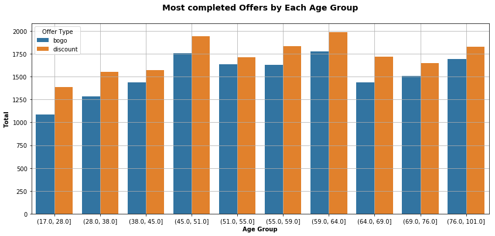

```python
# Plot Most completed Offers by Each Age Group
plt.figure(figsize=(14, 6))
sb.countplot(x="age_bins", hue="offer_type", data=offer_completed)
plt.title('Most completed Offers by Each Age Group', y=1.05, fontsize=14, fontweight='bold')
plt.xlabel('Age Group', fontweight='bold')
plt.ylabel('Total', fontweight='bold')
plt.legend(title='Offer Type')
plt.grid();
```

*Customers of all age groups tend to complete discount offers more than bogo offers.*

*The highest number of offers was completed by customers of age 59-64, followed by 45-51, then 76-101.*

```python
males.head()
```

|  | person | age | gender | income | became_member_on | event | event_time | offer_type | offer_reward | earned_reward | amount | offer_id | channels | difficulty | offer_duration | age_bins |
| --- | --- | --- | --- | --- | --- | --- | --- | --- | --- | --- | --- | --- | --- | --- | --- | --- |
| 34 | e2127556f4f64592b11af22de27a7932 | 68 | M | 70000.0 | 20180426 | offer completed | 522 | bogo | 5.0 | 5.0 | NaN | 9b98b8c7a33c4b65b9aebfe6a799e6d9 | [web, email, mobile] | 5.0 | 7.0 | (64.0, 69.0] |
| 35 | e2127556f4f64592b11af22de27a7932 | 68 | M | 70000.0 | 20180426 | offer completed | 522 | discount | 2.0 | 2.0 | NaN | fafdcd668e3743c1bb461111dcafc2a4 | [web, email, mobile, social] | 10.0 | 10.0 | (64.0, 69.0] |
| 39 | 389bc3fa690240e798340f5a15918d5c | 65 | M | 53000.0 | 20180209 | offer completed | 60 | bogo | 5.0 | 5.0 | NaN | f19421c1d4aa40978ebb69ca19b0e20d | [web, email, mobile, social] | 5.0 | 5.0 | (64.0, 69.0] |
| 47 | 389bc3fa690240e798340f5a15918d5c | 65 | M | 53000.0 | 20180209 | offer completed | 498 | discount | 2.0 | 2.0 | NaN | 2906b810c7d4411798c6938adc9daaa5 | [web, email, mobile] | 10.0 | 7.0 | (64.0, 69.0] |
| 48 | 389bc3fa690240e798340f5a15918d5c | 65 | M | 53000.0 | 20180209 | offer completed | 498 | bogo | 5.0 | 5.0 | NaN | 9b98b8c7a33c4b65b9aebfe6a799e6d9 | [web, email, mobile] | 5.0 | 7.0 | (64.0, 69.0] |

```python
females.head()
```

|  | person | age | gender | income | became_member_on | event | event_time | offer_type | offer_reward | earned_reward | amount | offer_id | channels | difficulty | offer_duration | age_bins |
| --- | --- | --- | --- | --- | --- | --- | --- | --- | --- | --- | --- | --- | --- | --- | --- | --- |
| 5 | 0610b486422d4921ae7d2bf64640c50b | 55 | F | 112000.0 | 20170715 | offer completed | 528 | bogo | 5.0 | 5.0 | NaN | 9b98b8c7a33c4b65b9aebfe6a799e6d9 | [web, email, mobile] | 5.0 | 7.0 | (51.0, 55.0] |
| 9 | 78afa995795e4d85b5d9ceeca43f5fef | 75 | F | 100000.0 | 20170509 | offer completed | 132 | bogo | 5.0 | 5.0 | NaN | 9b98b8c7a33c4b65b9aebfe6a799e6d9 | [web, email, mobile] | 5.0 | 7.0 | (69.0, 76.0] |
| 20 | 78afa995795e4d85b5d9ceeca43f5fef | 75 | F | 100000.0 | 20170509 | offer completed | 510 | bogo | 10.0 | 10.0 | NaN | ae264e3637204a6fb9bb56bc8210ddfd | [email, mobile, social] | 10.0 | 7.0 | (69.0, 76.0] |
| 21 | 78afa995795e4d85b5d9ceeca43f5fef | 75 | F | 100000.0 | 20170509 | offer completed | 510 | bogo | 5.0 | 5.0 | NaN | f19421c1d4aa40978ebb69ca19b0e20d | [web, email, mobile, social] | 5.0 | 5.0 | (69.0, 76.0] |
| 71 | aa4862eba776480b8bb9c68455b8c2e1 | 61 | F | 57000.0 | 20170911 | offer completed | 210 | bogo | 10.0 | 10.0 | NaN | 4d5c57ea9a6940dd891ad53e9dbe8da0 | [web, email, mobile, social] | 10.0 | 5.0 | (59.0, 64.0] |

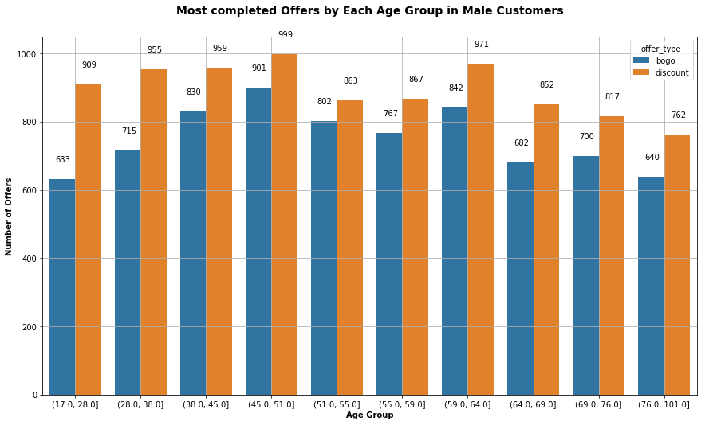

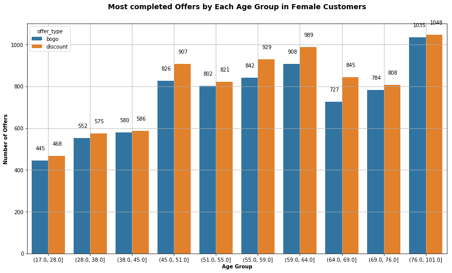

```python
# Most completed Offers by Each Age Group in Male Customers
plt.figure(figsize=(14.7, 8.27))
ax = sb.countplot(x="age_bins", hue="offer_type", data=males)

for p in ax.patches:
        ax.annotate(p.get_height(), (p.get_x()+0.1, p.get_height()+50)) # Show values on columns

plt.grid() # Show grid lines
plt.title('Most completed Offers by Each Age Group in Male Customers', y=1.05, fontsize=14, fontweight='bold')
plt.ylabel('Number of Offers', fontweight='bold')
plt.xlabel('Age Group', fontweight='bold')

# Most comleted Offers by Each Age Group in Female Customers
plt.figure(figsize=(14.7, 8.27))
ax = sb.countplot(x="age_bins", hue="offer_type", data=females)

for p in ax.patches:
        ax.annotate(p.get_height(), (p.get_x()+0.1, p.get_height()+50)) # Show values on columns

plt.grid()
plt.title('Most completed Offers by Each Age Group in Female Customers', y=1.05, fontsize=14, fontweight='bold')
plt.ylabel('Number of Offers', fontweight='bold')
plt.xlabel('Age Group', fontweight='bold');
```

*The highest number of offers was completed by male customers of age 45-51, followed by those of age 59-64.*

*The highest number of offers was completed by female customers of age 76-101, followed by those of age 59-64.*

## 6. Results

As mentioned, a student may choose to answer questions with data visualizations or other means that don't involve machine learning if a different approach best helps them address their question(s) of interest. So, I decided I will develop a set of heuristics to help determine what offer should be sent to each customer. Before answering any questions, let's first take a quicK look at some results.

**- Analysis quick results:**

- Age of most customers falls between 50 and 70 years.
- Oldest customers are 101 years old. There are 5 of them, actually, and 12 of 100 years old. Hmm... Interesting..
- Most customers beacme members between 2017 & 2018.
- Income of most customers falls between 50,000 and 75,000.
- 'Other' gender doesn't have significant influence on analysis results and is neglected through the whole analysis process.
- Percent of completed offers (including customers of unknown demographics)= 33579/76277 x 100 = 44.022%
- 66501 customers of known demographics received offers.
- Only 74.9% of csutomers who received offers viewed them.
- Only 32444 of the received offers were completed by customers of known demographics. That's 48.79%.
- Almost the same percent of offer types was received and viewed by both males and females.
- Percent of females who completed offers from those who received offers = 56.3701923077 %.
- Percent of males who completed offers from those who received offers = 43.1849773139 %
- Number of male customers who received, viewed, and completed offers is more than females.
- Number of female customers who completed offers is very close to male customers
- However, percent of females who completed offers is higher than that of males.
- This could suggest that males tend to make purchases without offers (but this needs further analysis, of course).

### A. Answering Questions

**Q1- Is there a correlation between income and purchase amount?**

- Although there is a direct correlation between customer income and their purchase amount, it seems there is a group of customers whose purchase is constant whatever their income is. Hmm.. Interesting!
- I believe Starbucks need to dig deeper into this to find what traits those customers have.
- Meanwhile, the company should target high income customers as they are willing to pay more.

**Q2- Do purchases correspond to age distribution?**

- Yes. The amount spent corresponds to age distribution. Customers between 50 & 70 years spend the most. I believe this indicates regular spending rate among all customers. In other words, customers of all age groups spend the same average value, thus the more the customers, the higher the amount they spend. So, the company should focus more on customer groups of higher member counts.

**Q3- Which demographic groups pays more in purchases?**

- In general, females spend the most (863695), but are very close to males (844890)
- According to age, females of age 43-58 spend the most while males of age 53-80 spend the most.

**Q4- Which demographic groups respond best to which offer type?**

- Both males and females responded more to discount offers.
- More males (54.4%) responded to discount offers than females (51.5%).
- More females (48.5%) responded to bogo offers than males (45.6%).
- Customers of all age groups tend to complete discount offers more than bogo offers.
- Collectively, customers of age 59-64 tend to complete offers the most. when viewed separately, the highest number of offers was completed by male customers of age 45-51, followed by those of age 59-64 while the highest number of offers was completed by female customers of age 76-101, followed by those of age 59-64.

### B. Justification

At a first look on the project, my impression was that it is a simple question that can be solved by analyzing customer purhcases and just targeting those who pay the most.

After a second thought I found that improvement could be made by analyzing offer types and how each group of customers responded to them so I started to additionally classify customers by age and gender and see how they responded to different offer types by analyzing their completed offers.

As discussed in the previouse section, I found a direct correlation between customer income and their purchase amounts. However, there seems a group of customers whose purchse is constant whatever there income is. Although a simple answer could be that they only need one cup of coffe in the morning as a daily habbit that won't chage with their income I still believe that Starbucks need to dig deeper into this to find what traits those customers have.

*Meanwhile, the company should target high income customers as they are willing to pay more.*

Then I thought of finding the age distribution of customers and comparing it to their purchases to find whether a specific age group paid more. I found out that the amount spent corresponds to age distribution. Customers between 50 & 70 years spend the most. I believe this indicates regular spending rate among all customers. In other words, customers of all age groups spend the same average value, thus the more the customers in a certain groupe, the higher the amount they spend.

*So, the company should focus more on customer groups of higher member counts.*

Now comes the improved part, a deeper demographic classification and comparison to customer response to offers by analyzing their completed offer..

- Both males and females responded more to discount offers although more females (48.5%) responded to bogo offers than males (45.6%).
- Customers of all age groups tend to complete discount offers more than bogo offers.
- Customers of age 59-64 tend to complete offers the most.

Well, it seems that neither gender nor age play a significant role here regarding the type of offer since both genders of all ages tend to complete the same offer type (discount). However it's valuable to note that customers of age group 59-64 tend to complete offers the most. This certainly makes sense when we recall the age group that spends the most (50-70).

It's also worth noting that the percent of females who completed offers is higher than that of males. Since the number of male customers who received, viewed, and completed offers is more than females and the number of female customers who completed offers is very close to male customers, this could suggest that males tend to make purchases without offers (but this needs further analysis, of course).

Now the picture pieces are starting to come together..

## 7. Conclusion

### A. Reflection

According to the problem statement, the basic task is to use the data to identify which groups of people are most responsive to each type of offer. After this analysis, I can now say that all customers are more responsive to discount offers than they are to bogo offers although more females (48.5%) responded to bogo offers than males (45.6%).

Since there is a direct correlation between customer income and the amount they spend, we can safely assume that Starbucks should focus more on targeting customers of higer income as they tend to pay more.

An interesting fact, however, that requires more research, is why there is a group of people whose purchase is not directly correlated to their income and keep a fixed payment amount.

On a side note, it was also interesting to find that some customers were 100 years old, and even more, who not only still make purchases from Starbucks, but they also use a mobile app. to do this.! Wow! Now that's what I call adaptation to technology..

**As a final conclusive result, the company should focus more on sending discount offers to higher income customers of all genders in the age group 59-64 since this group tends to pay more and complete more offers.**

### B. Improvement

Well, I believe the data still hides a lot under the hat!

However 2 significant points seen during my analysis are:

1- The group of customers whose purchse amount is constant whaatever there income is.

2- Dot males actually tend to make purchases without offers?

Trying to assess the customers purchase behavior and what a certain demographic group will buy when not receiving any offers so you won't send them any can save the company more money.

**The possibilities are endless!**